Tarea 9 - Agrupamiento Jerarquico por Hclust

Por: César Omar López Arteaga

Abril 2024

# PREGUNTA 1

Bajar el archivo Clase_9.R

**Solucion**

```r
# clasificación jerarquica con hclust
# Pero se necesita de calcular la matriz  de distancias previamente.

# Carga de la data Linnerud
dat <- read.csv("F:/R IMCA/TAREA 9/DESCARGA_DATA/Linnerud.csv",header=TRUE,row.names=1)

# Verificar la estructura de los datos
str(dat)
```

```
## 'data.frame':    20 obs. of  6 variables:
##  $ Peso        : int  191 189 193 162 189 182 211 167 176 154 ...
##  $ Cintura     : int  36 37 38 35 35 36 38 34 31 33 ...
##  $ Pulsaciones : int  50 52 58 62 46 56 56 60 74 56 ...
##  $ Lanzamientos: int  5 2 12 12 13 4 8 6 15 17 ...
##  $ Flexiones   : int  162 110 101 105 155 101 101 125 200 251 ...
##  $ Saltos      : int  60 60 101 37 58 42 38 40 40 250 ...
```

```r
# Visualizar los primeros registros de los datos sin modificar
head(dat,n=10)
```

|  | Peso | Cintura | Pulsaciones | Lanzamientos | Flexiones | Saltos |
| --- | --- | --- | --- | --- | --- | --- |
| 1 | 191 | 36 | 50 | 5 | 162 | 60 |
| 2 | 189 | 37 | 52 | 2 | 110 | 60 |
| 3 | 193 | 38 | 58 | 12 | 101 | 101 |
| 4 | 162 | 35 | 62 | 12 | 105 | 37 |
| 5 | 189 | 35 | 46 | 13 | 155 | 58 |
| 6 | 182 | 36 | 56 | 4 | 101 | 42 |
| 7 | 211 | 38 | 56 | 8 | 101 | 38 |
| 8 | 167 | 34 | 60 | 6 | 125 | 40 |
| 9 | 176 | 31 | 74 | 15 | 200 | 40 |
| 10 | 154 | 33 | 56 | 17 | 251 | 250 |

```r
n <- dim(dat)[1];n
```

```
## [1] 20
```

```r
lin.dis   <- dist(dat); round(lin.dis,3)         # matriz de distancias (Euclidianas)
```

```
##          1       2       3       4       5       6       7       8       9
## 2   52.173
## 3   74.317  43.761
## 4   69.376  38.562  71.400
## 5   11.747  46.797  70.250  62.666
## 6   64.521  21.794  60.614  23.281  58.335
## 7   68.220  33.196  65.673  49.790  62.722  29.614
## 8   49.497  34.612  70.915  21.794  44.204  28.792  50.517
## 9   52.631  96.737 118.849  96.948  57.637 101.543 107.014  77.408
## 10 213.492 239.714 215.119 258.484 217.773 258.314 266.081 245.526 217.984
## 11  53.666  34.957  70.788  21.095  45.365  27.477  47.518  15.937  83.917
## 12  77.660 117.009 113.437 131.263  82.722 132.559 141.071 113.864  79.480
## 13  80.523 120.715 120.785 129.603  85.790 133.854 144.395 112.134  71.021
## 14 126.079  84.558  91.471 103.947 121.384  83.875  64.730 111.328 169.228
## 15  96.571  50.100  77.750  50.150  89.554  36.152  37.974  63.103 134.759
## 16  78.861 118.191 111.086 139.707  85.434 135.890 136.890 122.061  85.820
## 17 108.959  62.466  88.470  49.970 102.137  44.844  55.642  67.676 142.766
## 18  78.968 126.214 135.834 132.699  84.747 137.080 146.226 113.217  57.983
## 19  74.081 121.128 132.586 125.734  79.284 130.947 140.371 106.433  50.180
## 20  78.384  56.232  81.823  27.875  73.892  46.637  75.100  34.000  98.803
##         10      11      12      13      14      15      16      17      18
## 2
## 3
## 4
## 5
## 6
## 7
## 8
## 9
## 10
## 11 249.734
## 12 141.711 118.571
## 13 149.650 118.085  20.372
## 14 299.184 107.369 191.580 198.514
## 15 287.181  57.149 165.768 168.565  61.790
## 16 144.783 126.850  37.921  50.705 181.304 167.018
## 17 296.275  63.340 175.502 176.403  76.629  22.226 179.803
## 18 171.473 118.541  41.364  31.875 204.206 171.388  64.428 179.900
## 19 178.933 111.535  45.793  35.071 199.539 165.263  68.110 173.396   9.798
## 20 251.704  40.447 127.848 123.637 126.586  72.650 142.046  66.963 128.328
##         19
## 2
## 3
## 4
## 5
## 6
## 7
## 8
## 9
## 10
## 11
## 12
## 13
## 14
## 15
## 16
## 17
## 18
## 19
## 20 121.713
```

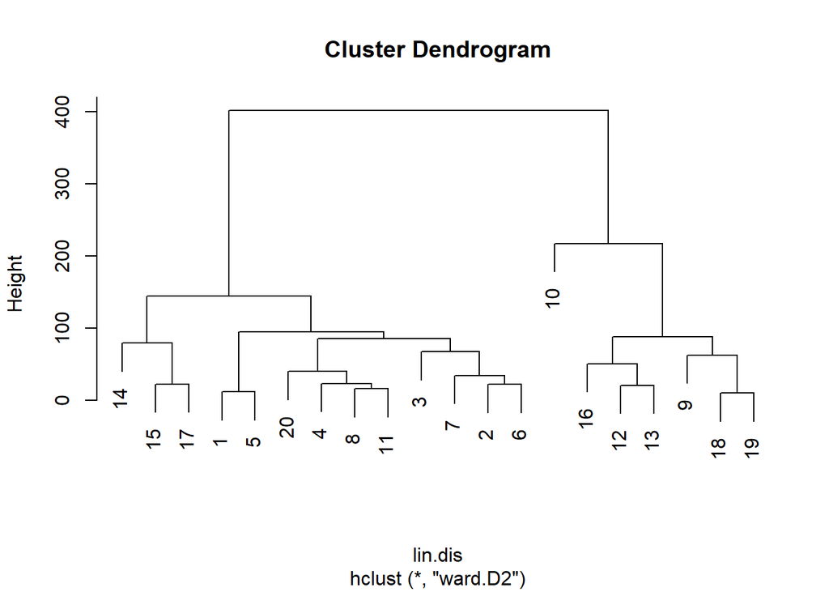

```r
lin.clust <- hclust(lin.dis,method="ward.D2")    # jerarquía ("Ward")
plot(lin.clust)                                  # gráfico dendrograma
```

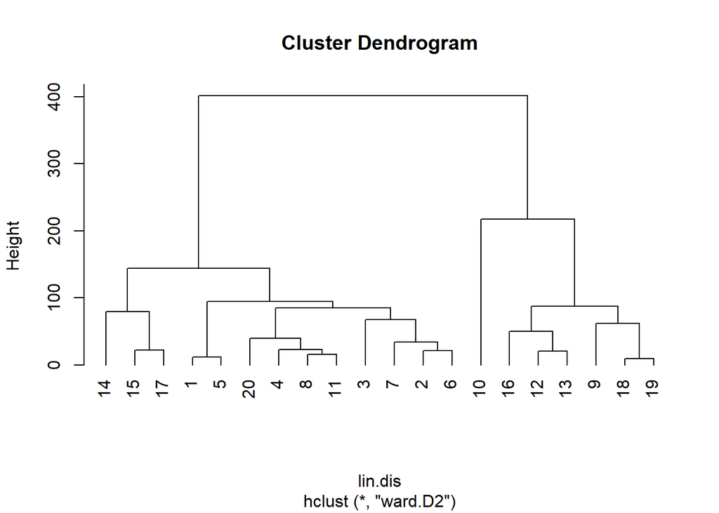

```r
plot(lin.clust,hang=-1)                          # gráfico mejor
```

```r
lin.clust
```

```
##
## Call:
## hclust(d = lin.dis, method = "ward.D2")
##
## Cluster method   : ward.D2
## Distance         : euclidean
## Number of objects: 20
```

```r
str(lin.clust)
```

```
## List of 7
##  $ merge      : int [1:19, 1:2] -18 -1 -8 -12 -2 -15 -4 -7 -20 -16 ...
##  $ height     : num [1:19] 9.8 11.7 15.9 20.4 21.8 ...
##  $ order      : int [1:20] 14 15 17 1 5 20 4 8 11 3 ...
##  $ labels     : chr [1:20] "1" "2" "3" "4" ...
##  $ method     : chr "ward.D2"
##  $ call       : language hclust(d = lin.dis, method = "ward.D2")
##  $ dist.method: chr "euclidean"
##  - attr(*, "class")= chr "hclust"
```

```r
# hclust brinda muchas salidas: se les vamos a salir todas
summary(lin.clust)
```

```
##             Length Class  Mode
## merge       38     -none- numeric
## height      19     -none- numeric
## order       20     -none- numeric
## labels      20     -none- character
## method       1     -none- character
## call         3     -none- call
## dist.method  1     -none- character
```

```r
lin.clust$merge        # las parejas de nodos que se juntan
```

```
##       [,1] [,2]
##  [1,]  -18  -19
##  [2,]   -1   -5
##  [3,]   -8  -11
##  [4,]  -12  -13
##  [5,]   -2   -6
##  [6,]  -15  -17
##  [7,]   -4    3
##  [8,]   -7    5
##  [9,]  -20    7
## [10,]  -16    4
## [11,]   -9    1
## [12,]   -3    8
## [13,]  -14    6
## [14,]    9   12
## [15,]   10   11
## [16,]    2   14
## [17,]   13   16
## [18,]  -10   15
## [19,]   17   18
```

```r
lin.clust$height       # el nivel de junctión
```

```
##  [1]   9.797959  11.747340  15.937377  20.371549  21.794495  22.226111
##  [7]  22.992752  34.073450  39.860172  50.342163  62.353829  67.394362
## [13]  79.343137  85.195364  87.882497  94.710348 144.225589 217.155419
## [19] 401.177895
```

```r
lin.clust$order        # el orden de las hojas
```

```
##  [1] 14 15 17  1  5 20  4  8 11  3  7  2  6 10 16 12 13  9 18 19
```

```r
lin.clust$labels       # nombres
```

```
##  [1] "1"  "2"  "3"  "4"  "5"  "6"  "7"  "8"  "9"  "10" "11" "12" "13" "14" "15"
## [16] "16" "17" "18" "19" "20"
```

```r
lin.clust$method       # método
```

```
## [1] "ward.D2"
```

```r
lin.clust$call         # fila de llamada
```

```
## hclust(d = lin.dis, method = "ward.D2")
```

```r
lin.clust$dist.method  # la distancia
```

```
## [1] "euclidean"
```

```r
part <- cutree(lin.clust, k = 1:(n-1)); part  # así se hacen todas las particiones posibles
```

```
##    1 2 3 4 5 6 7 8 9 10 11 12 13 14 15 16 17 18 19
## 1  1 1 1 1 1 1 1 1 1  1  1  1  1  1  1  1  1  1  1
## 2  1 1 1 1 2 2 2 2 2  2  2  2  2  2  2  2  2  2  2
## 3  1 1 1 1 2 2 2 2 3  3  3  3  3  3  3  3  3  3  3
## 4  1 1 1 1 2 2 3 3 4  4  4  4  4  4  4  4  4  4  4
## 5  1 1 1 1 1 1 1 1 1  1  1  1  1  1  1  1  1  1  5
## 6  1 1 1 1 2 2 2 2 2  2  2  2  2  2  2  5  5  5  6
## 7  1 1 1 1 2 2 2 2 2  2  2  2  5  5  5  6  6  6  7
## 8  1 1 1 1 2 2 3 3 4  4  4  4  4  6  6  7  7  7  8
## 9  1 2 2 2 3 3 4 4 5  5  5  5  6  7  7  8  8  8  9
## 10 1 2 3 3 4 4 5 5 6  6  6  6  7  8  8  9  9  9 10
## 11 1 1 1 1 2 2 3 3 4  4  4  4  4  6  6  7  7 10 11
## 12 1 2 2 2 3 5 6 6 7  7  7  7  8  9  9 10 10 11 12
## 13 1 2 2 2 3 5 6 6 7  7  7  7  8  9  9 10 11 12 13
## 14 1 1 1 4 5 6 7 7 8  8  8  8  9 10 10 11 12 13 14
## 15 1 1 1 4 5 6 7 8 9  9  9  9 10 11 11 12 13 14 15
## 16 1 2 2 2 3 5 6 6 7  7 10 10 11 12 12 13 14 15 16
## 17 1 1 1 4 5 6 7 8 9  9  9  9 10 11 13 14 15 16 17
## 18 1 2 2 2 3 3 4 4 5 10 11 11 12 13 14 15 16 17 18
## 19 1 2 2 2 3 3 4 4 5 10 11 11 12 13 14 15 16 17 18
## 20 1 1 1 1 2 2 3 3 4  4  4 12 13 14 15 16 17 18 19
```

```r
############################################################################################
# elección de la partición: inicialización
maxcl    <- n-1
ngr      <- c((maxcl):1)
wss      <- rep(0,maxcl)
wssd     <- wss
wssd2    <- wss
##########################################################################################
# estadísticas para el índice de la jerarquía
indx     <- lin.clust$height
Di       <- c(0,indx[2:maxcl] - indx[1:(maxcl-1)])    # diferencias índice de Ward
Di2      <- c(0,Di[2:maxcl] - Di[1:(maxcl-1)])        # diferencias segundas
########################################################################
# función que calcula la suma de cuadrados centrados

css <- function(data) {            # Centered sum of squares of a data.frame
       sum(scale(data, center = TRUE, scale = FALSE)^2)
}
########################################################################
# función que particiona los datos según los grupos eligidos y calcula
# la wss correspondiente
wrap <- function(i, hc, x) {          #  i = # of clusters, hc = hclust, x = data
        cl  <- cutree(hc, i)          # gets the partition in i groups
        spl <- split(x, cl)           # splits the data in classes
        wss <- sum(sapply(spl, css))  # computes the wss
        wss
}
########################################################################
# se aplica wrap a cada partición
wss      <- rep(0,maxcl)
length(wss)
```

```
## [1] 19
```

```r
for (i in 1:maxcl) {
  wss[i] <- wrap(i,lin.clust,dat)             # suma de cuadratos dentro
}
# se calculan estadísticas correspondientes
Dw       <- -c(wss[2:maxcl] - wss[1:(maxcl-1)],0); Dw     # las dos diferencias
```

```
##  [1] 80471.8516 23578.2381 10400.5103  4485.0250  3861.6667  3629.1250
##  [7]  3147.6667  2271.0000  1944.0000  1267.1667   794.4167   580.5000
## [13]   264.3333   247.0000   237.5000   207.5000   127.0000    69.0000
## [19]     0.0000
```

```r
Dw2      <- -c(Dw[2:maxcl] - Dw[1:(maxcl-1)],0); Dw2
```

```
##  [1] 56893.61355 13177.72784  5915.48526   623.35833   232.54167   481.45833
##  [7]   876.66667   327.00000   676.83333   472.75000   213.91667   316.16667
## [13]    17.33333     9.50000    30.00000    80.50000    58.00000    69.00000
## [19]     0.00000
```

```r
tss      <- wss[1]                            # suma de cuadratos total
bss      <- tss - wss                         # suma de cuadratos entre
# índice de Calinski-Harabász
df1      <- c(1:(maxcl))                      # número de grupos
df2      <- (n-c(1:maxcl))                    # número de observaciones - grupos
CH       <- (bss/df1)/(wss/df2)               # Calinski-Harabász
# se c onstruye la tabla de resultados
index    <- cbind(c((maxcl):1),lin.clust$merge,indx,Di,Di2,rev(wss),rev(Dw),rev(Dw2),CH)
rownames(index)   <- c(1:maxcl)
colnames(index)   <- c("ngr","g1","g2","index","Dindex","D2index","wss","Dwss","Dwss2","CH")
index
```

```
##    ngr  g1  g2      index      Dindex     D2index        wss       Dwss
## 1   19 -18 -19   9.797959   0.0000000   0.0000000     48.000     0.0000
## 2   18  -1  -5  11.747340   1.9493812   1.9493812    117.000    69.0000
## 3   17  -8 -11  15.937377   4.1900373   2.2406562    244.000   127.0000
## 4   16 -12 -13  20.371549   4.4341713   0.2441340    451.500   207.5000
## 5   15  -2  -6  21.794495   1.4229459  -3.0112254    689.000   237.5000
## 6   14 -15 -17  22.226111   0.4316161  -0.9913299    936.000   247.0000
## 7   13  -4   3  22.992752   0.7666417   0.3350257   1200.333   264.3333
## 8   12  -7   5  34.073450  11.0806976  10.3140559   1780.833   580.5000
## 9   11 -20   7  39.860172   5.7867222  -5.2939754   2575.250   794.4167
## 10  10 -16   4  50.342163  10.4819903   4.6952681   3842.417  1267.1667
## 11   9  -9   1  62.353829  12.0116665   1.5296762   5786.417  1944.0000
## 12   8  -3   8  67.394362   5.0405327  -6.9711338   8057.417  2271.0000
## 13   7 -14   6  79.343137  11.9487749   6.9082422  11205.083  3147.6667
## 14   6   9  12  85.195364   5.8522271  -6.0965478  14834.208  3629.1250
```

[output cut: 25 more lines]

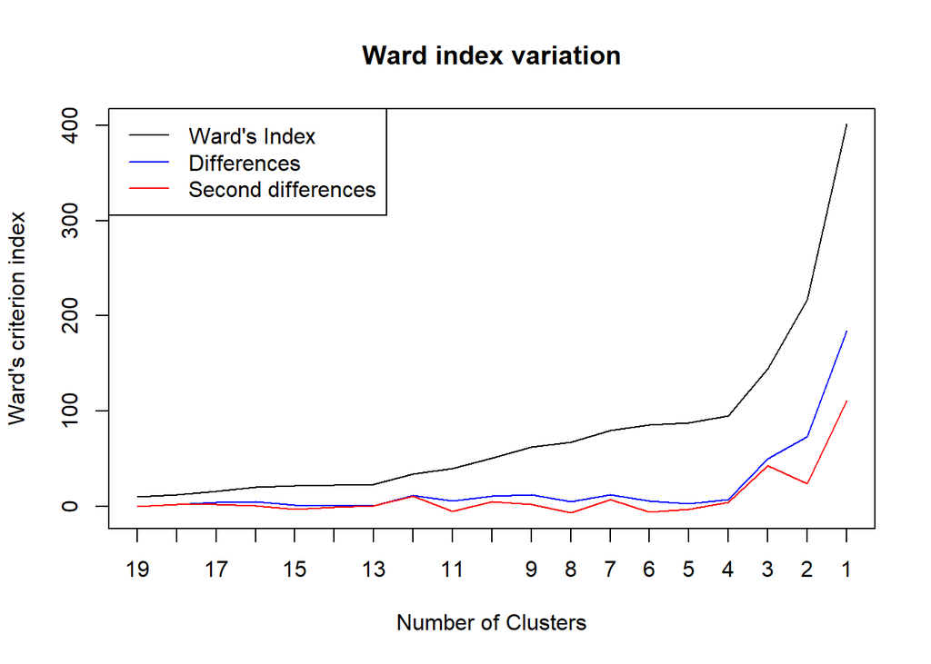

```r
###### gráfico del índice
plot(c(1:maxcl),indx, type="l", xlab="Number of Clusters", ylim = c(min(indx,Di,Di2),max(indx,Di,Di2)),xaxt="n",
     ylab="Ward's criterion index", main = "Ward index variation")
axis(1,at=c(1:maxcl),labels=ngr)
lines(c(1:maxcl),Di,col="blue")
lines(c(1:maxcl),Di2,col="red")
legend("topleft",legend=c("Ward's Index","Differences","Second differences"),col=c("black","blue","red"),lty=1)
```

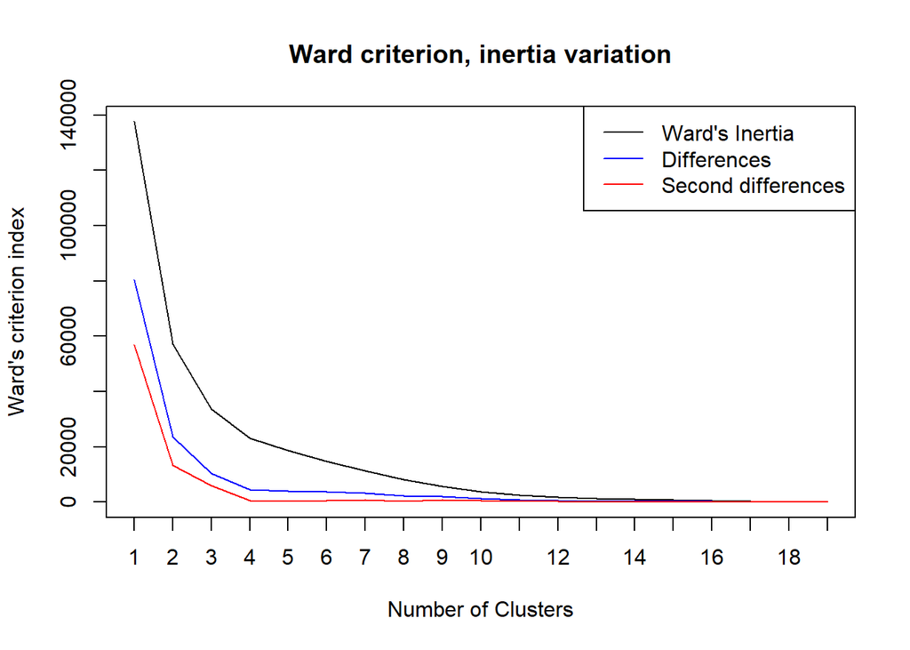

```r
###### gráfico de las inercias
plot(1:maxcl, wss, type="l", xlab="Number of Clusters", ylim = c(min(wss,Dw,Dw2),max(wss,Dw,Dw2)),xaxt="n",
     ylab="Ward's criterion index", main = "Ward criterion, inertia variation")
axis(1,at=c(1:maxcl),labels=1:maxcl)
lines(1:maxcl, Dw,col="blue")
lines(1:maxcl, Dw2,col="red")
legend("topright",legend=c("Ward's Inertia","Differences","Second differences"),col=c("black","blue","red"),lty=1)
```

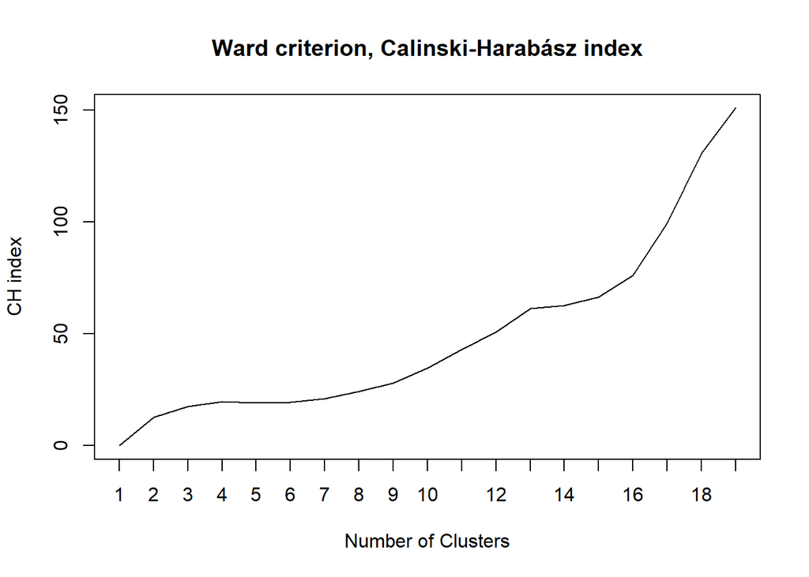

```r
###### gráfico de Calinski-Harabász
plot(1:maxcl, CH, type="l", xlab="Number of Clusters", xaxt="n",
     ylab="CH index", main = "Ward criterion, Calinski-Harabász index")
axis(1,at=c(1:maxcl),labels=c(1:maxcl))
```

```r
###########################################################################################
# estudio de una partición
ncl    <- 4                  # por ejemplo en 4 clases, pero cuidado, pues ncl es empleado
                             # para eligir la cuarta partición en part, ya que se han
                             # hechas todas con cutree. Si no, hay que encuentrar cual se
                             # corresponde en part a ncl clases.
parti  <- part[,ncl]; parti  # clase de cada unidad
```

```
##  1  2  3  4  5  6  7  8  9 10 11 12 13 14 15 16 17 18 19 20
##  1  1  1  1  1  1  1  1  2  3  1  2  2  4  4  2  4  2  2  1
```

```r
# para saber la lista de unidades por grupo en una partición y el promedio de las variables
apply(dat,2,mean)
```

```
##         Peso      Cintura  Pulsaciones Lanzamientos    Flexiones       Saltos
##       178.60        35.40        56.10         9.45       145.55        70.30
```

```r
clases = list()
dat_clases = split(dat,parti)
for (k in 1:ncl) {   # se buscan los nombres de las unidades
  clases$ind[[k]] <- rownames(part)[which(part[,ncl]==k)] # identifica ls puntos,
  clases$mean[[k]]<- apply(dat_clases[[k]],2,mean)        # cálcula los promédios
}
clases                                                    # lista de salida
```

```
## $ind
## $ind[[1]]
##  [1] "1"  "2"  "3"  "4"  "5"  "6"  "7"  "8"  "11" "20"
##
## $ind[[2]]
## [1] "9"  "12" "13" "16" "18" "19"
##
## $ind[[3]]
## [1] "10"
##
## $ind[[4]]
## [1] "14" "15" "17"
##
##
## $mean
## $mean[[1]]
##         Peso      Cintura  Pulsaciones Lanzamientos    Flexiones       Saltos
##        179.1         35.6         55.8          8.1        119.0         51.7
##
## $mean[[2]]
##         Peso      Cintura  Pulsaciones Lanzamientos    Flexiones       Saltos
##    168.50000     33.33333     59.66667     13.33333    215.00000     88.83333
##
## $mean[[3]]
##         Peso      Cintura  Pulsaciones Lanzamientos    Flexiones       Saltos
##          154           33           56           17          251          250
##
## $mean[[4]]
##         Peso      Cintura  Pulsaciones Lanzamientos    Flexiones       Saltos
##   205.333333    39.666667    50.000000     3.666667    60.000000    35.333333
```

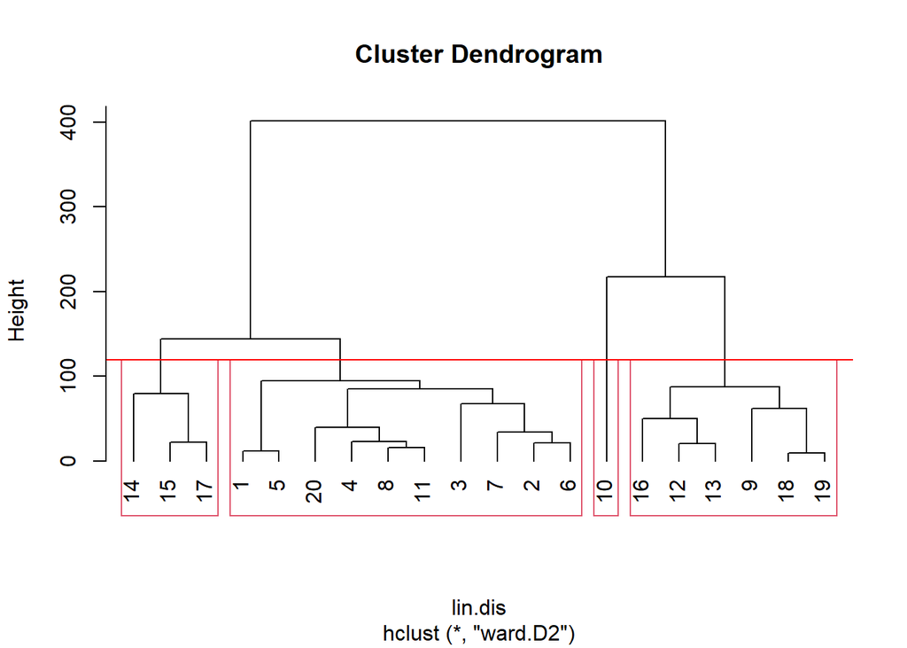

```r
###### dendrograma con clases
plot(lin.clust,hang=-1)
rect.hclust(lin.clust,k=ncl)
abline(h=(mean(indx[maxcl-ncl+c(1,2)])),col="red")
```

```r
#########################################################################
# clasificación jerárquica con similitud
# se trabaja con Ellenberg

# Carga de la data Linnerud
ell <- read.csv("F:/R IMCA/TAREA 9/DESCARGA_DATA/Ellenberg.csv",header=TRUE,row.names=1)

# Verificar la estructura de los datos
str(ell)
```

```
## 'data.frame':    76 obs. of  25 variables:
##  $ X1 : int  0 1 0 1 1 1 1 1 1 0 ...
##  $ X2 : int  1 1 1 0 1 1 1 0 0 1 ...
##  $ X3 : int  0 1 0 1 0 1 0 0 0 1 ...
##  $ X4 : int  1 1 0 1 0 1 0 1 1 0 ...
##  $ X5 : int  1 1 1 0 0 1 0 0 1 1 ...
##  $ X6 : int  1 1 1 0 0 1 0 0 0 1 ...
##  $ X7 : int  1 1 1 0 0 1 0 0 0 1 ...
##  $ X8 : int  1 1 0 0 0 1 0 0 1 1 ...
##  $ X9 : int  1 1 1 1 1 1 1 1 1 1 ...
##  $ X10: int  1 1 1 1 1 1 1 1 1 1 ...
##  $ X11: int  1 1 0 0 0 1 0 0 1 1 ...
##  $ X12: int  1 1 1 0 0 1 0 0 1 1 ...
##  $ X13: int  1 1 1 0 0 1 0 0 1 1 ...
##  $ X14: int  1 1 0 0 0 1 0 0 0 1 ...
##  $ X15: int  1 1 0 1 0 1 0 0 1 1 ...
##  $ X16: int  1 1 1 0 0 1 1 0 0 1 ...
##  $ X17: int  1 1 1 0 0 1 0 0 1 1 ...
##  $ X18: int  1 1 1 0 0 1 0 0 0 1 ...
##  $ X19: int  1 1 0 0 0 1 0 0 1 1 ...
##  $ X20: int  1 1 1 0 0 1 0 0 1 1 ...
##  $ X21: int  1 1 1 0 0 1 0 0 0 1 ...
##  $ X22: int  1 1 1 0 0 1 0 0 0 1 ...
##  $ X23: int  1 1 0 0 0 1 0 0 1 1 ...
##  $ X24: int  1 1 1 1 0 1 0 0 1 1 ...
##  $ X25: int  1 1 0 0 0 1 0 0 0 1 ...
```

```r
# Visualizar los primeros registros de los datos sin modificar
head(ell,n=10)
```

|  | X1 | X2 | X3 | X4 | X5 | X6 | X7 | X8 | X9 | X10 | X11 | X12 | X13 | X14 | X15 | X16 | X17 | X18 | X19 | X20 | X21 | X22 | X23 | X24 | X25 |
| --- | --- | --- | --- | --- | --- | --- | --- | --- | --- | --- | --- | --- | --- | --- | --- | --- | --- | --- | --- | --- | --- | --- | --- | --- | --- |
| Arre_elat | 0 | 1 | 0 | 1 | 1 | 1 | 1 | 1 | 1 | 1 | 1 | 1 | 1 | 1 | 1 | 1 | 1 | 1 | 1 | 1 | 1 | 1 | 1 | 1 | 1 |
| Dact_glom | 1 | 1 | 1 | 1 | 1 | 1 | 1 | 1 | 1 | 1 | 1 | 1 | 1 | 1 | 1 | 1 | 1 | 1 | 1 | 1 | 1 | 1 | 1 | 1 | 1 |
| Heli_pube | 0 | 1 | 0 | 0 | 1 | 1 | 1 | 0 | 1 | 1 | 0 | 1 | 1 | 0 | 0 | 1 | 1 | 1 | 0 | 1 | 1 | 1 | 0 | 1 | 0 |
| Brom_erec | 1 | 0 | 1 | 1 | 0 | 0 | 0 | 0 | 1 | 1 | 0 | 0 | 0 | 0 | 1 | 0 | 0 | 0 | 0 | 0 | 0 | 0 | 0 | 1 | 0 |
| Fest_ovin | 1 | 1 | 0 | 0 | 0 | 0 | 0 | 0 | 1 | 1 | 0 | 0 | 0 | 0 | 0 | 0 | 0 | 0 | 0 | 0 | 0 | 0 | 0 | 0 | 0 |
| Poa_prat | 1 | 1 | 1 | 1 | 1 | 1 | 1 | 1 | 1 | 1 | 1 | 1 | 1 | 1 | 1 | 1 | 1 | 1 | 1 | 1 | 1 | 1 | 1 | 1 | 1 |
| Briz_medi | 1 | 1 | 0 | 0 | 0 | 0 | 0 | 0 | 1 | 1 | 0 | 0 | 0 | 0 | 0 | 1 | 0 | 0 | 0 | 0 | 0 | 0 | 0 | 0 | 0 |
| Koel_pyra | 1 | 0 | 0 | 1 | 0 | 0 | 0 | 0 | 1 | 1 | 0 | 0 | 0 | 0 | 0 | 0 | 0 | 0 | 0 | 0 | 0 | 0 | 0 | 0 | 0 |
| Fest_rubr | 1 | 0 | 0 | 1 | 1 | 0 | 0 | 1 | 1 | 1 | 1 | 1 | 1 | 0 | 1 | 0 | 1 | 0 | 1 | 1 | 0 | 0 | 1 | 1 | 0 |
| Fest_prat | 0 | 1 | 1 | 0 | 1 | 1 | 1 | 1 | 1 | 1 | 1 | 1 | 1 | 1 | 1 | 1 | 1 | 1 | 1 | 1 | 1 | 1 | 1 | 1 | 1 |

```r
#ell <- read.csv("Ellenberg.csv",header=TRUE,row.names=1); head(ell)
n = dim(ell)[1]
p = dim(ell)[2]
ell.c.sim <- matrix(0,nrow=p,p)
# se construye la matriz de similitud entre columnas según Sorensen
for (i in 1:p) {
  for (j in 1:i) {
    if (i ==j)  {
      ell.c.sim[i,i] <- 1
    } else {
      t  <- table(ell[,i],ell[,j])  # tabla de contingencia
      a  <- t[1,1]
      b  <- t[1,2]
      c  <- t[2,1]
      d  <- t[2,2]
      so <- 2*a / (2*a + b + c)    # sorensen
      ell.c.sim[i,j] <- so         # valores en la primera mitad
      ell.c.sim[j,i] <- so         # también otra mitad
    }
  }
}
ell.c.sim
```

```
##            [,1]      [,2]      [,3]      [,4]      [,5]      [,6]      [,7]
##  [1,] 1.0000000 0.7800000 0.7959184 0.8865979 0.7311828 0.6451613 0.6000000
##  [2,] 0.7800000 1.0000000 0.7800000 0.7272727 0.7578947 0.7157895 0.7173913
##  [3,] 0.7959184 0.7800000 1.0000000 0.7835052 0.7096774 0.6451613 0.6444444
##  [4,] 0.8865979 0.7272727 0.7835052 1.0000000 0.7173913 0.6086957 0.6067416
##  [5,] 0.7311828 0.7578947 0.7096774 0.7173913 1.0000000 0.8181818 0.7529412
##  [6,] 0.6451613 0.7157895 0.6451613 0.6086957 0.8181818 1.0000000 0.7764706
##  [7,] 0.6000000 0.7173913 0.6444444 0.6067416 0.7529412 0.7764706 1.0000000
##  [8,] 0.6521739 0.6595745 0.6304348 0.6593407 0.7816092 0.8045977 0.7142857
##  [9,] 0.7956989 0.7368421 0.7526882 0.7391304 0.7045455 0.6363636 0.5647059
## [10,] 0.7659574 0.7291667 0.7446809 0.7741935 0.6966292 0.6067416 0.5813953
## [11,] 0.6597938 0.6868687 0.5979381 0.6458333 0.7608696 0.7608696 0.6966292
## [12,] 0.7021277 0.7291667 0.7021277 0.7096774 0.7865169 0.8089888 0.7441860
## [13,] 0.6590909 0.6666667 0.6136364 0.6206897 0.8674699 0.8433735 0.7750000
## [14,] 0.6875000 0.7142857 0.6666667 0.6947368 0.7252747 0.7692308 0.6818182
```

[output cut: 89 more lines]

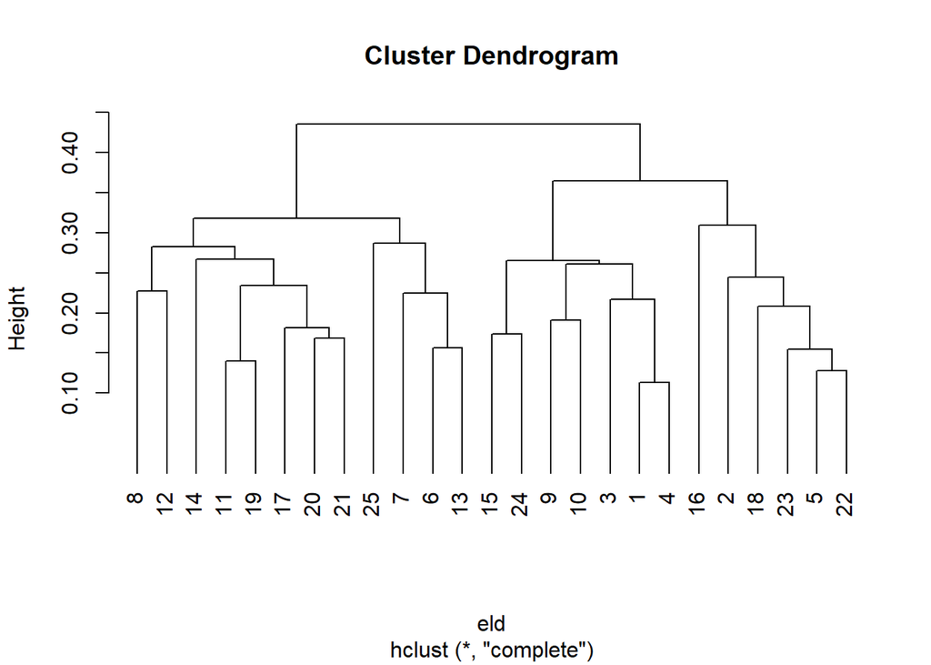

```r
# se transforma en disimilitud y se hace la jerarquía
eld       <- as.dist(1-(ell.c.sim))
ell.c.cpl <- hclust(eld,method="complete") # distancia máxima
# gráfico del dendrograma
plot(ell.c.cpl,hang=-0.1)
```

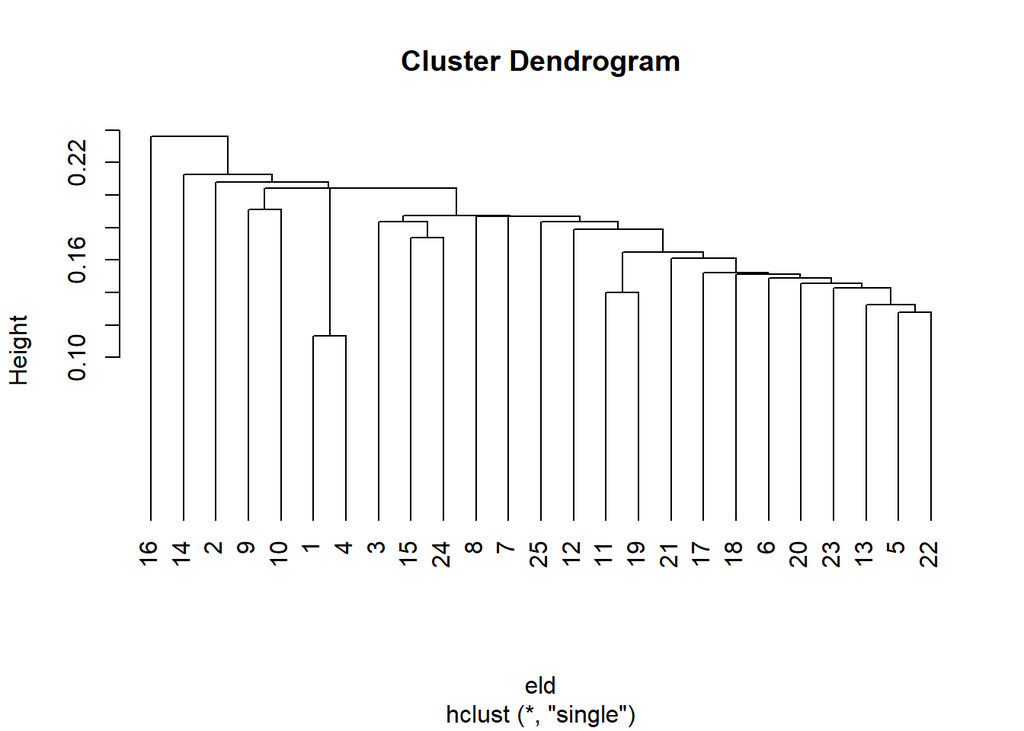

```r
ell.s.cpl <- hclust(eld,method="single")   # distancia mínima
plot(ell.s.cpl,hang=-0.1)
```

```r
########################################################################
# trabajamos con la máxima distancia
maxcl    <- p-1
wss      <- rep(0,maxcl)
wssd     <- wss
wssd2    <- wss
wss      <- ell.c.cpl$height
for (i in 1:maxcl) {
  if (i>1) {
    wssd[i]  <- wss[i]-wss[i-1]
  }
  if (i>2) wssd2[i] <- wssd[i]-wssd[i-1]
}
index             <- cbind(c(maxcl:1),wss,wssd,wssd2)
rownames(index)   <- c(1:maxcl)
colnames(index)   <- c("ngr","SSW","D","D2")
index                                         # tabla de resultados
```

```
##    ngr       SSW           D            D2
## 1   24 0.1134021 0.000000000  0.0000000000
## 2   23 0.1276596 0.014257513  0.0000000000
## 3   22 0.1400000 0.012340426 -0.0019170871
## 4   21 0.1546392 0.014639175  0.0022987497
## 5   20 0.1566265 0.001987331 -0.0126518445
## 6   19 0.1685393 0.011912820  0.0099254891
## 7   18 0.1739130 0.005373718 -0.0065391022
## 8   17 0.1818182 0.007905138  0.0025314207
## 9   16 0.1910112 0.009193054  0.0012879158
## 10  15 0.2083333 0.017322097  0.0081290432
## 11  14 0.2164948 0.008161512 -0.0091605854
## 12  13 0.2250000 0.008505155  0.0003436426
## 13  12 0.2272727 0.002272727 -0.0062324274
## 14  11 0.2340426 0.006769826  0.0044970986
## 15  10 0.2448980 0.010855406  0.0040855801
## 16   9 0.2608696 0.015971606  0.0051162000
## 17   8 0.2653061 0.004436557 -0.0115350488
## 18   7 0.2666667 0.001360544 -0.0030760130
## 19   6 0.2826087 0.015942029  0.0145814848
## 20   5 0.2873563 0.004747626 -0.0111944028
## 21   4 0.3095238 0.022167488  0.0174198615
## 22   3 0.3181818 0.008658009 -0.0135094790
## 23   2 0.3647059 0.046524064  0.0378660555
## 24   1 0.4352941 0.070588235  0.0240641711
```

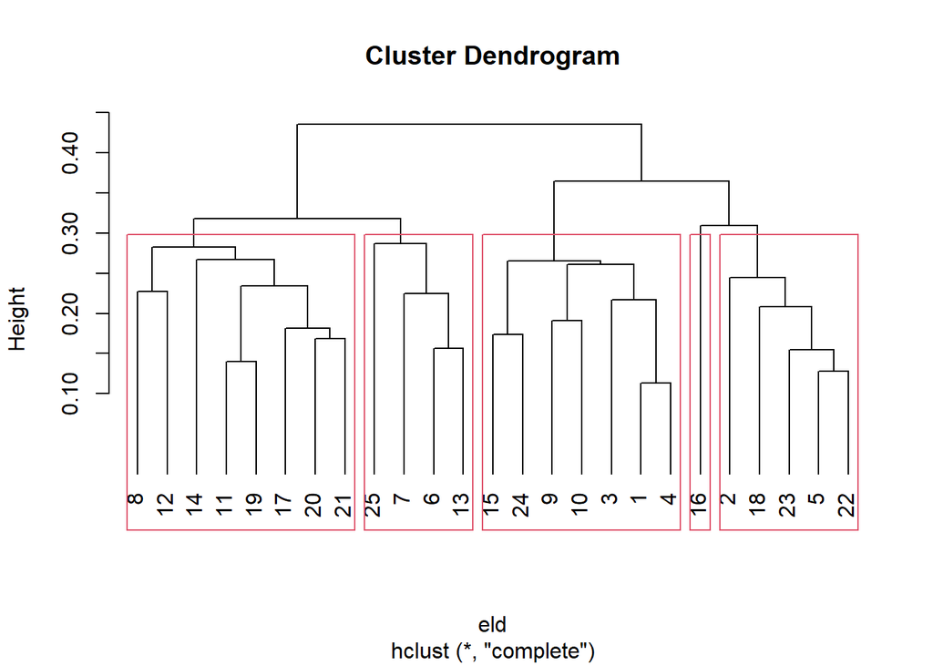

```r
plot(ell.c.cpl,hang=-0.1)                     # gráfico con clases
rect.hclust(ell.c.cpl,k=5)                    # se dibujan rectangulos para clases
```

```r
########################################################################
```

# PREGUNTA 2

Con los datos de Iris, correr la clasificación jerárquica (distancia Euclideana y ward.D2) con 3 grupos y con los grupos que el CH sugiere.

**Solucion**

Se descargara el archivo Iris.csv a una carpeta local, luego se cargara el archivo y se mostrara la estructura de la data, la cual llamaremos **“iris”**, luego se muestra la tabla con las primeras 10 observaciones.

```r
# Carga de la data Iris
iris_bruto<- read.csv("F:/R IMCA/TAREA 9/DESCARGA_DATA/Iris.csv",header=TRUE,row.names=1)

iris.labels<-iris_bruto$Species
table(iris.labels)
```

```
## iris.labels
##     setosa versicolor  virginica
##         50         50         50
```

```r
#excluyendo la columna species el cual esta en posicion 5
iris_data <- iris_bruto[1:4]

# Verificar la estructura de los datos
str(iris_data)
```

```
## 'data.frame':    150 obs. of  4 variables:
##  $ Sepal.length: num  5.1 4.9 4.7 4.6 5 5.4 4.6 5 4.4 4.9 ...
##  $ Sepal.width : num  3.5 3 3.2 3.1 3.6 3.9 3.4 3.4 2.9 3.1 ...
##  $ Petal.length: num  1.4 1.4 1.3 1.5 1.4 1.7 1.4 1.5 1.4 1.5 ...
##  $ Petal.width : num  0.2 0.2 0.2 0.2 0.2 0.4 0.3 0.2 0.2 0.1 ...
```

```r
# Visualizar los primeros registros de los datos sin modificar
head(iris_data,n=10)
```

|  | Sepal.length | Sepal.width | Petal.length | Petal.width |
| --- | --- | --- | --- | --- |
| 1 | 5.1 | 3.5 | 1.4 | 0.2 |
| 2 | 4.9 | 3.0 | 1.4 | 0.2 |
| 3 | 4.7 | 3.2 | 1.3 | 0.2 |
| 4 | 4.6 | 3.1 | 1.5 | 0.2 |
| 5 | 5.0 | 3.6 | 1.4 | 0.2 |
| 6 | 5.4 | 3.9 | 1.7 | 0.4 |
| 7 | 4.6 | 3.4 | 1.4 | 0.3 |
| 8 | 5.0 | 3.4 | 1.5 | 0.2 |
| 9 | 4.4 | 2.9 | 1.4 | 0.2 |
| 10 | 4.9 | 3.1 | 1.5 | 0.1 |

```r
#escalando la data
#iris<-scale(iris_data)

#asignacion de la data para el calculo
iris<-iris_data
```

```r
#calculo de la matriz de distancia euclideana
iris.dis<-dist(iris)

# Verificar la estructura de los datos
str(iris.dis)
```

```
##  'dist' num [1:11175] 0.539 0.51 0.648 0.141 0.616 ...
##  - attr(*, "Size")= int 150
##  - attr(*, "Labels")= chr [1:150] "1" "2" "3" "4" ...
##  - attr(*, "Diag")= logi FALSE
##  - attr(*, "Upper")= logi FALSE
##  - attr(*, "method")= chr "euclidean"
##  - attr(*, "call")= language dist(x = iris)
```

```r
#matriz de distancias (Euclidianas), solo muestra los primeros 7x7 valores
as.matrix(iris.dis)[1:7, 1:7]
```

```
##           1         2         3         4         5         6         7
## 1 0.0000000 0.5385165 0.5099020 0.6480741 0.1414214 0.6164414 0.5196152
## 2 0.5385165 0.0000000 0.3000000 0.3316625 0.6082763 1.0908712 0.5099020
## 3 0.5099020 0.3000000 0.0000000 0.2449490 0.5099020 1.0862780 0.2645751
## 4 0.6480741 0.3316625 0.2449490 0.0000000 0.6480741 1.1661904 0.3316625
## 5 0.1414214 0.6082763 0.5099020 0.6480741 0.0000000 0.6164414 0.4582576
## 6 0.6164414 1.0908712 1.0862780 1.1661904 0.6164414 0.0000000 0.9949874
## 7 0.5196152 0.5099020 0.2645751 0.3316625 0.4582576 0.9949874 0.0000000
```

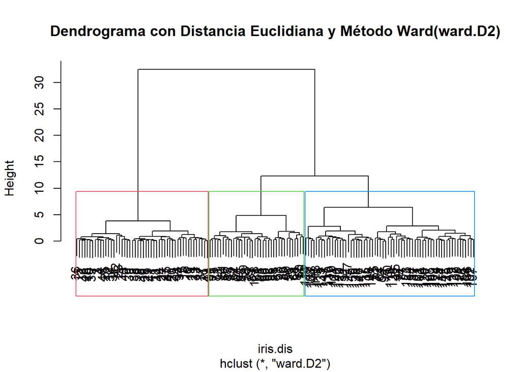

```r
library(knitr)
# Realizar el agrupamiento jerárquico con el método de Ward
grupo <- hclust(d=iris.dis, method = "ward.D2")

# Dibujar el dendrograma
plot(grupo, main = "Dendrograma con Distancia Euclidiana y Método Ward(ward.D2)")
rect.hclust(grupo,k=3,borde=2:5)
```

```r
# Puedes usar la función cutree() para cortar el dendrograma en un número específico de grupos
num_grupos <- 3
grupos_cortados <- cutree(grupo, num_grupos)

# Imprimir los grupos resultantes
print(grupos_cortados)
```

```
##   1   2   3   4   5   6   7   8   9  10  11  12  13  14  15  16  17  18  19  20
##   1   1   1   1   1   1   1   1   1   1   1   1   1   1   1   1   1   1   1   1
##  21  22  23  24  25  26  27  28  29  30  31  32  33  34  35  36  37  38  39  40
##   1   1   1   1   1   1   1   1   1   1   1   1   1   1   1   1   1   1   1   1
##  41  42  43  44  45  46  47  48  49  50  51  52  53  54  55  56  57  58  59  60
##   1   1   1   1   1   1   1   1   1   1   2   3   2   2   2   2   3   2   2   2
##  61  62  63  64  65  66  67  68  69  70  71  72  73  74  75  76  77  78  79  80
##   2   2   2   3   3   2   2   2   2   3   2   3   2   3   2   2   3   3   2   2
##  81  82  83  84  85  86  87  88  89  90  91  92  93  94  95  96  97  98  99 100
##   2   2   2   3   3   2   2   2   3   2   2   2   3   2   2   2   3   2   2   3
## 101 102 103 104 105 106 107 108 109 110 111 112 113 114 115 116 117 118 119 120
##   3   3   3   3   3   3   3   3   3   3   3   3   3   3   3   3   3   3   3   3
## 121 122 123 124 125 126 127 128 129 130 131 132 133 134 135 136 137 138 139 140
##   3   3   3   3   3   3   3   2   3   3   3   3   3   3   3   3   3   3   3   3
## 141 142 143 144 145 146 147 148 149 150
##   3   3   3   3   3   3   3   3   3   3
```

```r
#creacion de la tabla t1
t1<-table(grupos_cortados,iris.labels)
kable(t1, caption = "Tabla Metodo Ward.D2 y distancia Euclideana",format = "markdown",align="c")
```

Tabla Metodo Ward.D2 y distancia Euclideana

[output not shown]

```r
############################################################################################
# elección de la partición: inicialización
n <- dim(iris)[1]
maxcl    <- n-1
ngr      <- c((maxcl):1)
wss      <- rep(0,maxcl)
wssd     <- wss
wssd2    <- wss
##########################################################################################
# estadísticas para el índice de la jerarquía
indx     <- grupo$height
Di       <- c(0,indx[2:maxcl] - indx[1:(maxcl-1)])    # diferencias índice de Ward
Di2      <- c(0,Di[2:maxcl] - Di[1:(maxcl-1)])        # diferencias segundas
########################################################################
# función que calcula la suma de cuadrados centrados

css <- function(data) {            # Centered sum of squares of a data.frame
      sum(scale(data, center = TRUE, scale = FALSE)^2)
}
########################################################################
# función que particiona los datos según los grupos eligidos y calcula
# la wss correspondiente
wrap <- function(i, hc, x) {          #  i = # of clusters, hc = hclust, x = data
        cl  <- cutree(hc, i)          # gets the partition in i groups
        spl <- split(x, cl)           # splits the data in classes
        wss <- sum(sapply(spl, css))  # computes the wss
        wss
}
########################################################################
# se aplica wrap a cada partición
wss      <- rep(0,maxcl)
#length(wss)
for (i in 1:maxcl) {
  wss[i] <- wrap(i,grupo,iris)             # suma de cuadratos dentro
}
# se calculan estadísticas correspondientes
Dw       <- -c(wss[2:maxcl] - wss[1:(maxcl-1)],0)    # las dos diferencias
Dw2      <- -c(Dw[2:maxcl] - Dw[1:(maxcl-1)],0)

tss      <- wss[1]                            # suma de cuadratos total
bss      <- tss - wss                         # suma de cuadratos entre
# índice de Calinski-Harabász
df1      <- c(1:(maxcl))                      # número de grupos
df2      <- (n-c(1:maxcl))                    # número de observaciones - grupos
CH       <- (bss/df1)/(wss/df2)               # Calinski-Harabász
# se c onstruye la tabla de resultados
index    <- cbind(c((maxcl):1),grupo$merge,indx,Di,Di2,rev(wss),rev(Dw),rev(Dw2),CH)
rownames(index)   <- c(1:maxcl)
colnames(index)   <- c("ngr","g1","g2","index","Dindex","D2index","wss","Dwss","Dwss2","CH")
index
```

```
##     ngr   g1   g2      index       Dindex       D2index         wss
## 1   149  -52  -93  0.0000000 0.000000e+00  0.000000e+00   0.0000000
## 2   148   -8  -40  0.1000000 1.000000e-01  1.000000e-01   0.0050000
## 3   147   -1  -18  0.1000000 3.330669e-16 -1.000000e-01   0.0100000
## 4   146  -10  -35  0.1000000 2.775558e-17 -3.053113e-16   0.0150000
## 5   145  -79  -83  0.1000000 8.326673e-17  5.551115e-17   0.0200000
## 6   144  -11  -49  0.1000000 4.440892e-16  3.608225e-16   0.0250000
## 7   143   -5  -38  0.1414214 4.142136e-02  4.142136e-02   0.0350000
## 8   142  -20  -22  0.1414214 2.775558e-17 -4.142136e-02   0.0450000
## 9   141  -30  -31  0.1414214 2.775558e-17  0.000000e+00   0.0550000
## 10  140  -67  -88  0.1414214 0.000000e+00 -2.775558e-17   0.0650000
## 11  139 -108 -144  0.1414214 0.000000e+00  0.000000e+00   0.0750000
## 12  138 -131 -132  0.1414214 0.000000e+00  0.000000e+00   0.0850000
## 13  137   -9  -39  0.1414214 1.665335e-16  1.665335e-16   0.0950000
## 14  136   -4  -48  0.1414214 1.665335e-16  0.000000e+00   0.1050000
```

[output cut: 285 more lines]

**Comentario**

Con los datos de Iris, al correr la clasificación jerárquica con la distancia Euclideana y el metodo ward.D2, con el indice CH suguiere que la agrupacion se en cinco grupos $(CH=390.7879)$.

# PREGUNTA 3

Correr también la misma tabla con la distancia de Manhattan (sin CH) empleando métodos “single” y “complete”.

**Solucion**

Con el codigo de la parte 2, se correra la clasificacion jerarquica con los metodos “single” y “complete”, en ambos casos se usara la metrica Manhattan.

- Se inicia con los calculos previos del calculo de matriz de distancia con el metodo manhattan

```r
#calculo de la matriz de distancia manhattan
iris.dis   <- dist(iris,method = "manhattan")

# Verificar la estructura de los datos
str(iris.dis)
```

```
##  'dist' num [1:11175] 0.7 0.8 1 0.2 1.2 ...
##  - attr(*, "Size")= int 150
##  - attr(*, "Labels")= chr [1:150] "1" "2" "3" "4" ...
##  - attr(*, "Diag")= logi FALSE
##  - attr(*, "Upper")= logi FALSE
##  - attr(*, "method")= chr "manhattan"
##  - attr(*, "call")= language dist(x = iris, method = "manhattan")
```

```r
#matriz de distancias (Euclidianas), solo muestra los primeros 7x7 valores
as.matrix(iris.dis)[1:7, 1:7]
```

```
##     1   2   3   4   5   6   7
## 1 0.0 0.7 0.8 1.0 0.2 1.2 0.7
## 2 0.7 0.0 0.5 0.5 0.7 1.9 0.8
## 3 0.8 0.5 0.0 0.4 0.8 2.0 0.5
## 4 1.0 0.5 0.4 0.0 1.0 2.0 0.5
## 5 0.2 0.7 0.8 1.0 0.0 1.2 0.7
## 6 1.2 1.9 2.0 2.0 1.2 0.0 1.7
## 7 0.7 0.8 0.5 0.5 0.7 1.7 0.0
```

- En este apartado se hace el agrupamiento jerarquico con el metodo Single

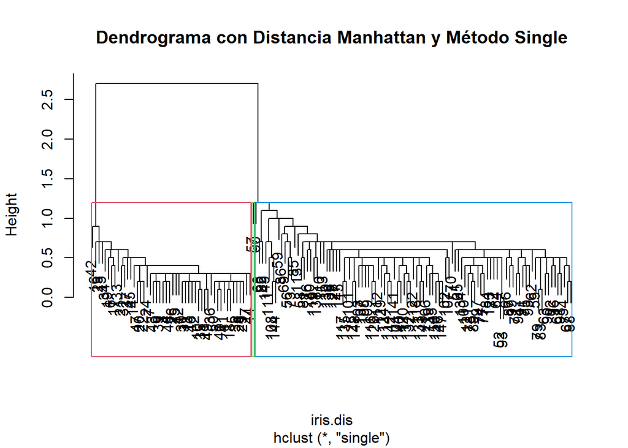

```r
########################### AGRUPAMIENTO CON EL METODO SINGLE Y METRICA MANHATTAN

# Realizar el agrupamiento jerárquico con el método de single
grupo <- hclust(d=iris.dis, method = "single")

# Dibujar el dendrograma
plot(grupo, main = "Dendrograma con Distancia Manhattan y Método Single")
rect.hclust(grupo,k=3,borde=2:5)
```

```r
# Puedes usar la función cutree() para cortar el dendrograma en un número específico de grupos
num_grupos <- 3
grupos_cortados <- cutree(grupo, num_grupos)

#creacion de la tabla t2
t2<-table(grupos_cortados,iris.labels)

# Imprimir la tabla con título utilizando kable
kable(t2, caption = "Tabla Metodo Single y distancia de manhattan",format = "markdown",align="c")
```

Tabla Metodo Single y distancia de manhattan

| setosa | versicolor | virginica |
| --- | --- | --- |
| 50 | 0 | 0 |
| 0 | 50 | 49 |
| 0 | 0 | 1 |

- En este apartado se hace el agrupamiento jerarquico con el metodo Complete

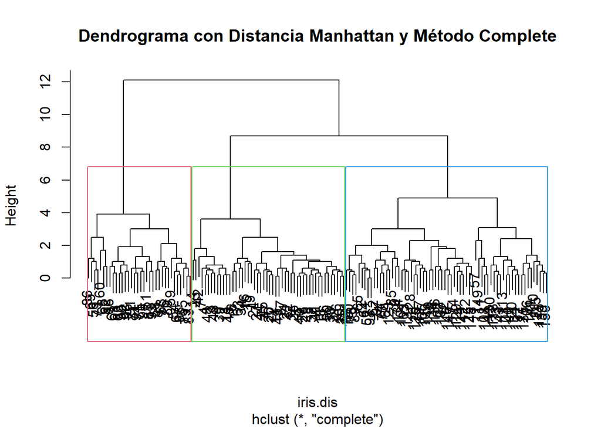

```r
########################### AGRUPAMIENTO CON EL METODO COMPLETE Y METRICA MANHATTAN

# Realizar el agrupamiento jerárquico con el método de complete
grupo <- hclust(d=iris.dis, method = "complete")

# Dibujar el dendrograma
plot(grupo, main = "Dendrograma con Distancia Manhattan y Método Complete")
rect.hclust(grupo,k=3,borde=2:5)
```

```r
# Puedes usar la función cutree() para cortar el dendrograma en un número específico de grupos
num_grupos <- 3
grupos_cortados <- cutree(grupo, num_grupos)

#creacion de la tabla t2
t3<-table(grupos_cortados,iris.labels)

# Imprimir la tabla con título utilizando kable
kable(t3, caption = "Tabla Metodo Complete y distancia de manhattan",format = "markdown",align="c")
```

Tabla Metodo Complete y distancia de manhattan

| setosa | versicolor | virginica |
| --- | --- | --- |
| 50 | 0 | 0 |
| 0 | 0 | 34 |
| 0 | 50 | 16 |

# PREGUNTA 4

¿Cual es la mejor clasificación? Cuales flores están mal clasificados en todas estas análisis?

**Solucion**

Para esta seccion se analizara los tres casos anteriores los cuales son:

- Clasificacion con el Metodo Ward.D2 y distancia Euclideana
- Clasificacion con el Metodo Single y distancia de manhattan
- Clasificacion con el Metodo Complete y distancia de manhattan

A continuacion se pasara mostrar cada tabla y se hara un analisis de cada una:

```r
#tabla t1 impresion
for(i in 1:1){
cat("Tabla Metodo Ward.D2 y distancia Euclideana\n")
print(t1)
}
```

```
## Tabla Metodo Ward.D2 y distancia Euclideana
##                iris.labels
## grupos_cortados setosa versicolor virginica
##               1     50          0         0
##               2      0          1        35
##               3      0         49        15
```

De la Tabla Metodo Ward.D2 y distancia Euclideana anterior se puede observar:

- Toda la especie de Setosa (n=50), estan clasificado en el cluster 1
- Un gran numero de la especie Versicolor (n=49), estan clasificado en el cluster 3, uno de ellos(n=1) se ha clasificado en el clauster 2
- Un gran numero de la especie Virginia (n=35) se han clasificado en el cluster 2, algunos de ellos (n=15) se han clasificado en el cluster 3

El error cometido en esta clasificacion seria de $Error1=16/150=10.66\%$

```r
#tabla t2 impresion
for(i in 1:1){
cat("Tabla Metodo Single y distancia de manhattan\n")
print(t2)
}
```

```
## Tabla Metodo Single y distancia de manhattan
##                iris.labels
## grupos_cortados setosa versicolor virginica
##               1     50          0         0
##               2      0         50        49
##               3      0          0         1
```

El error cometido en esta clasificacion seria de $Error2=49/150=32.66\%$

```r
# tabla t3 impresion
for(i in 1:1){
cat("Tabla Metodo Complete y distancia de manhattan\n")
print(t3)
}
```

```
## Tabla Metodo Complete y distancia de manhattan
##                iris.labels
## grupos_cortados setosa versicolor virginica
##               1     50          0         0
##               2      0          0        34
##               3      0         50        16
```

De la tabla del Metodo Complete y distancia de manhattan anterior se puede observar:

- Toda la especie de Setosa (n=50), estan clasificado en el cluster 1
- Toda la especie Versicolor (n=50), estan clasificado en el cluster 3
- Un gran numero de la especie Virginia (n=34) se han clasificado en el cluster 2, algunos de ellos (n=16) se han clasificado en el cluster 3

El error cometido en esta clasificacion seria de $Error3=16/150=10.66\%$

**Comentario**

De los errores encontrados en las tres tablas observamos que el que tiene menor error se da un empate con el metodo Ward.D2 y el metodo Complete los cuales tienen en mismo error(Error=10.66%) con lo cual la tabla t1 y t3,son el mejor clasificacion jerarquica. Se observa que en las tres clasificaciones la especie Virginia lo clasifica con errores, poniendo parte de su especie en un cluster indevido.

# PREGUNTA 5

Calcular la razón de correlación y su tabla de “breakdown” sobre los grupos elegidos.

**Solucion**

Se trabajara con el agrupamiento jerarquico con menor error, el cual corresponde al metodo Ward.D2 con metrica euclideana. Asi tenemos tenemos los tres agrupamientos que hace el algoritmo, los cuales pasamos a identificar segun la data original. El criterio es el siguiente:

- Grupo 1, el cual corresponde a la especie setosa
- Grupo 2, el cual corresponde a la especie virginica
- Grupo 3, el cual corresponde a la especie versicolor

```r
# Carga de la data Iris
iris_bruto<- read.csv("F:/R IMCA/TAREA 9/DESCARGA_DATA/Iris.csv",header=TRUE,row.names=1)

iris.labels<-iris_bruto$Species
table(iris.labels)
```

```
## iris.labels
##     setosa versicolor  virginica
##         50         50         50
```

```r
#excluyendo la columna species el cual esta en posicion 5
iris_data <- iris_bruto[1:4]

#asignacion de la data para el calculo
iris<-iris_data

#calculo de la matriz de distancia euclideana
iris.dis<-dist(iris)

# Realizar el agrupamiento jerárquico con el método de Ward
grupo <- hclust(d=iris.dis, method = "ward.D2")

# Puedes usar la función cutree() para cortar el dendrograma en un número específico de grupos
num_grupos <- 3
grupos_cortados <- cutree(grupo, num_grupos)

#creacion de la tabla t1
t1<-table(grupos_cortados,iris.labels)
kable(t1, caption = "Tabla Metodo Ward.D2 y distancia Euclideana",format = "markdown",align="c")
```

Tabla Metodo Ward.D2 y distancia Euclideana

| setosa | versicolor | virginica |
| --- | --- | --- |
| 50 | 0 | 0 |
| 0 | 1 | 35 |
| 0 | 49 | 15 |

```r
#tabla t1 impresion
for(i in 1:1){
cat("Tabla Metodo Ward.D2 y distancia Euclideana\n")
print(t1)
}
```

```
## Tabla Metodo Ward.D2 y distancia Euclideana
##                iris.labels
## grupos_cortados setosa versicolor virginica
##               1     50          0         0
##               2      0          1        35
##               3      0         49        15
```

Se pasara a tranformar el dataframe para que tenga las etiquetas de la clasificacion y poder ver mas detalle del agrupamiento de la data:

```r
#Comparamos con la data real
Species <- factor(grupos_cortados,levels =1:3, labels = c("setosa","virginica","versicolor"))
iris_test <- cbind( iris_bruto[,1:4],Species)
error <- sum(!iris_test$Species==iris_bruto[[5]])
table(iris_test$Species,iris_bruto[[5]])
```

```
##
##              setosa versicolor virginica
##   setosa         50          0         0
##   virginica       0          1        35
##   versicolor      0         49        15
```

```r
# Convertir a character
iris_test$Species <- as.character(iris_test$Species)

#visualizando la estructura de la data
head(iris_test,n=10)
```

|  | Sepal.length | Sepal.width | Petal.length | Petal.width | Species |
| --- | --- | --- | --- | --- | --- |
| 1 | 5.1 | 3.5 | 1.4 | 0.2 | setosa |
| 2 | 4.9 | 3.0 | 1.4 | 0.2 | setosa |
| 3 | 4.7 | 3.2 | 1.3 | 0.2 | setosa |
| 4 | 4.6 | 3.1 | 1.5 | 0.2 | setosa |
| 5 | 5.0 | 3.6 | 1.4 | 0.2 | setosa |
| 6 | 5.4 | 3.9 | 1.7 | 0.4 | setosa |
| 7 | 4.6 | 3.4 | 1.4 | 0.3 | setosa |
| 8 | 5.0 | 3.4 | 1.5 | 0.2 | setosa |
| 9 | 4.4 | 2.9 | 1.4 | 0.2 | setosa |
| 10 | 4.9 | 3.1 | 1.5 | 0.1 | setosa |

Se hara la tabla breakdown sobre los tres grupos resultantes de la clasificación.

```r
#Total de observaciones de la variable 1
n_t = length(iris_test[,1])

#Media de las observaciones de la variable 1
m_t = mean(iris_test[,1])

#Varianza de las observaciones de la variable 1
v_t = var(iris_test[,1])*(n_t-1)/n_t

#Desviacon Standar de las observaciones de la variable 1
s_t = sqrt(v_t)

#Coeficiente de variacion de las observaciones de la variable 1
cvt = s_t/m_t

#Agrupamiento de las estadisticas totales
total=rbind(n_t,m_t,v_t,s_t,cvt)

#Estadisticas por varible categorica (Variable 5)
n_unit=table(iris_test[,5])

#MEdia por categorica (Variable 5)
mean=tapply(iris_test[,1],iris_test[,5],mean)

#Varianza por categorica (Variable 5)
var=tapply(iris_test[,1],iris_test[,5],var)
var=var*(n_unit-1)/n_unit

#Desviacion Standar por categorica (Variable 5)
stdev=sqrt(var)
cv=stdev/mean

#Agrupamiento de las estadisticas parciales por variable categorica
brk=rbind(n_unit,mean,var,stdev,cv)

#Agrupamiento de la estadisticas por categoria (Var 5) contra la estadistica global(var 1)
brtot1=cbind(brk,total)
colnames(brtot1) = c(colnames(brk),"total")
brtot1
```

```
##             setosa  versicolor   virginica       total
## n_unit 50.00000000 64.00000000 36.00000000 150.0000000
## mean    5.00600000  5.92031250  6.86944444   5.8433333
## var     0.12176400  0.22318115  0.23489969   0.6811222
## stdev   0.34894699  0.47242052  0.48466451   0.8253013
## cv      0.06970575  0.07979655  0.07055367   0.1412381
```

La razon de correlacion sera:

```r
#La razón de correlación se puede calcular en dos maneras bajo esta tabla
e = sum(n_unit*(mean-m_t)^2) / (n_t*v_t)
cat("Razon de correlacion(e):",e)
```

```
## Razon de correlacion(e): 0.7178364
```

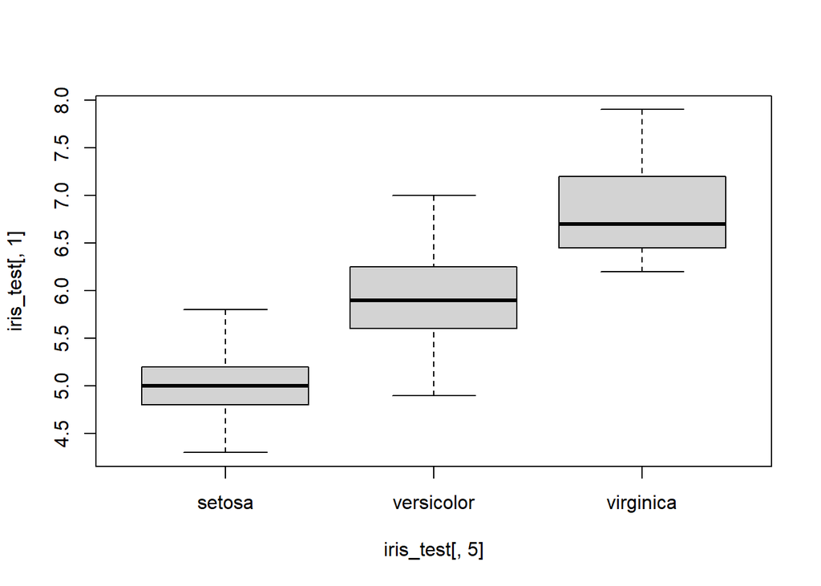

```r
boxplot(iris_test[,1]~iris_test[,5])
```

# PREGUNTA 6

Estandarizar los datos de Iris, empleando el comando scale(X, center=TRUE,scale=TRUE), con X el archivo Iris, limitadamente a las cuatro mediciones, y re-correr las análisis (solo Euclidean y ward.D2)

**Solucion**

Para este apattado se correra la data iris, pero antes de aplicarle el agrupamiento jerarquico se procedera a standarizar la data inicial.

```r
# Carga de la data Iris
iris_bruto<- read.csv("F:/R IMCA/TAREA 9/DESCARGA_DATA/Iris.csv",header=TRUE,row.names=1)

#visualizacion de la cantidades por especie de la data original
iris.labels<-iris_bruto$Species
table(iris.labels)
```

```
## iris.labels
##     setosa versicolor  virginica
##         50         50         50
```

```r
#excluyendo la columna species el cual esta en posicion 5, creamos una data si esta variable categorica
iris_data <- iris_bruto[1:4]

# Verificar la estructura de los datos
str(iris_data)
```

```
## 'data.frame':    150 obs. of  4 variables:
##  $ Sepal.length: num  5.1 4.9 4.7 4.6 5 5.4 4.6 5 4.4 4.9 ...
##  $ Sepal.width : num  3.5 3 3.2 3.1 3.6 3.9 3.4 3.4 2.9 3.1 ...
##  $ Petal.length: num  1.4 1.4 1.3 1.5 1.4 1.7 1.4 1.5 1.4 1.5 ...
##  $ Petal.width : num  0.2 0.2 0.2 0.2 0.2 0.4 0.3 0.2 0.2 0.1 ...
```

```r
# Visualizar los primeros registros de los datos sin modificar
head(iris_data,n=10)
```

|  | Sepal.length | Sepal.width | Petal.length | Petal.width |
| --- | --- | --- | --- | --- |
| 1 | 5.1 | 3.5 | 1.4 | 0.2 |
| 2 | 4.9 | 3.0 | 1.4 | 0.2 |
| 3 | 4.7 | 3.2 | 1.3 | 0.2 |
| 4 | 4.6 | 3.1 | 1.5 | 0.2 |
| 5 | 5.0 | 3.6 | 1.4 | 0.2 |
| 6 | 5.4 | 3.9 | 1.7 | 0.4 |
| 7 | 4.6 | 3.4 | 1.4 | 0.3 |
| 8 | 5.0 | 3.4 | 1.5 | 0.2 |
| 9 | 4.4 | 2.9 | 1.4 | 0.2 |
| 10 | 4.9 | 3.1 | 1.5 | 0.1 |

```r
#escalando la data iris
iris<-scale(iris_data,center=TRUE,scale=TRUE)
```

```r
#calculo de la matriz de distancia euclideana
iris.dis<-dist(iris)

# Verificar la estructura de los datos
str(iris.dis)
```

```
##  'dist' num [1:11175] 1.172 0.843 1.1 0.259 1.035 ...
##  - attr(*, "Size")= int 150
##  - attr(*, "Labels")= chr [1:150] "1" "2" "3" "4" ...
##  - attr(*, "Diag")= logi FALSE
##  - attr(*, "Upper")= logi FALSE
##  - attr(*, "method")= chr "euclidean"
##  - attr(*, "call")= language dist(x = iris)
```

```r
for(i in 1:1){
#matriz de distancias (Euclidianas), solo muestra los primeros 7x7 valores
cat("Ploteo Matriz de Distancias(Euclideana),solo se imprime parte de la matriz(7x7)\n\n")
print(as.matrix(iris.dis)[1:7, 1:7])
}
```

```
## Ploteo Matriz de Distancias(Euclideana),solo se imprime parte de la matriz(7x7)
##
##           1         2         3         4         5         6         7
## 1 0.0000000 1.1722914 0.8427840 1.0999999 0.2592702 1.0349769 0.6591230
## 2 1.1722914 0.0000000 0.5216255 0.4325508 1.3818560 2.1739229 0.9953200
## 3 0.8427840 0.5216255 0.0000000 0.2829432 0.9882608 1.8477070 0.4955334
## 4 1.0999999 0.4325508 0.2829432 0.0000000 1.2459861 2.0937597 0.7029623
## 5 0.2592702 1.3818560 0.9882608 1.2459861 0.0000000 0.8971079 0.6790442
## 6 1.0349769 2.1739229 1.8477070 2.0937597 0.8971079 0.0000000 1.5150531
## 7 0.6591230 0.9953200 0.4955334 0.7029623 0.6790442 1.5150531 0.0000000
```

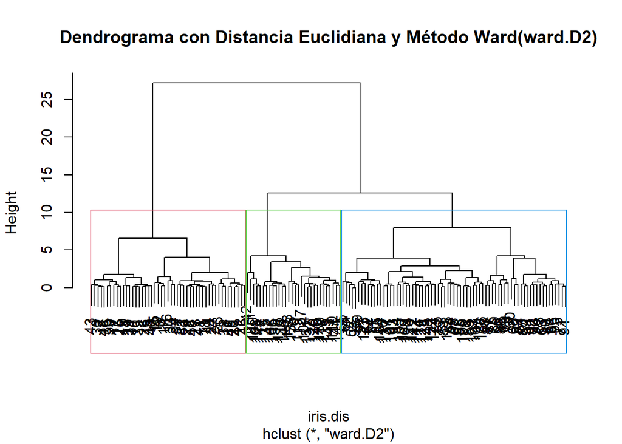

```r
# Realizar el agrupamiento jerárquico con el método de Ward
grupo <- hclust(d=iris.dis, method = "ward.D2")

# Dibujar el dendrograma
plot(grupo, main = "Dendrograma con Distancia Euclidiana y Método Ward(ward.D2)")
rect.hclust(grupo,k=3,borde=2:5)
```

```r
# Puedes usar la función cutree() para cortar el dendrograma en un número específico de grupos
num_grupos <- 3
grupos_cortados <- cutree(grupo, num_grupos)

# Imprimir los grupos resultantes
print(grupos_cortados)
```

```
##   1   2   3   4   5   6   7   8   9  10  11  12  13  14  15  16  17  18  19  20
##   1   1   1   1   1   1   1   1   1   1   1   1   1   1   1   1   1   1   1   1
##  21  22  23  24  25  26  27  28  29  30  31  32  33  34  35  36  37  38  39  40
##   1   1   1   1   1   1   1   1   1   1   1   1   1   1   1   1   1   1   1   1
##  41  42  43  44  45  46  47  48  49  50  51  52  53  54  55  56  57  58  59  60
##   1   2   1   1   1   1   1   1   1   1   3   3   3   3   3   3   2   3   3   3
##  61  62  63  64  65  66  67  68  69  70  71  72  73  74  75  76  77  78  79  80
##   3   3   3   3   3   3   3   3   3   2   3   3   3   3   3   3   3   3   3   3
##  81  82  83  84  85  86  87  88  89  90  91  92  93  94  95  96  97  98  99 100
##   3   3   3   3   3   3   3   3   3   3   3   3   3   3   3   3   3   3   3   3
## 101 102 103 104 105 106 107 108 109 110 111 112 113 114 115 116 117 118 119 120
##   3   3   3   2   3   2   3   2   3   2   2   3   2   3   2   3   2   2   2   2
## 121 122 123 124 125 126 127 128 129 130 131 132 133 134 135 136 137 138 139 140
##   3   3   3   3   3   3   3   3   3   2   2   2   2   3   2   3   3   2   2   2
## 141 142 143 144 145 146 147 148 149 150
##   2   3   2   2   2   2   2   3   2   2
```

```r
#creacion de la tabla t1
t4<-table(grupos_cortados,iris.labels)
# Imprimir la tabla con título utilizando kable
kable(t4, caption = "Tabla Metodo Ward.D2 y distancia Euclideana",format = "markdown",align="c")
```

Tabla Metodo Ward.D2 y distancia Euclideana

| setosa | versicolor | virginica |
| --- | --- | --- |
| 49 | 0 | 0 |
| 1 | 27 | 2 |
| 0 | 23 | 48 |

# PREGUNTA 7

¿Se encuentran resultados mejores o peores? (para el breakdown, solo emplear la clasificación salida, pero siempre las mediciones de Iris).

**Solucion**

- Grupo 1, el cual corresponde a la especie setosa
- Grupo 2, el cual corresponde a la especie versicolor
- Grupo 3, el cual corresponde a la especie virginica

```r
#escalando la data iris
iris<-scale(iris_data,center=TRUE,scale=TRUE)

#calculo de la matriz de distancia euclideana
iris.dis<-dist(iris)

# Realizar el agrupamiento jerárquico con el método de Ward
grupo <- hclust(d=iris.dis, method = "ward.D2")

# Puedes usar la función cutree() para cortar el dendrograma en un número específico de grupos
num_grupos <- 3
grupos_cortados <- cutree(grupo, num_grupos)

#creacion de la tabla t1
t2<-table(grupos_cortados,iris.labels)
kable(t2, caption = "Tabla Metodo Ward.D2 y distancia Euclideana",format = "markdown",align="c")
```

Tabla Metodo Ward.D2 y distancia Euclideana

| setosa | versicolor | virginica |
| --- | --- | --- |
| 49 | 0 | 0 |
| 1 | 27 | 2 |
| 0 | 23 | 48 |

Se pasara a tranformar el dataframe para que tenga las etiquetas de la clasificacion y poder ver mas detalle del agrupamiento de la data:

```r
#Comparamos con la data real
Species <- factor(grupos_cortados,levels =1:3, labels = c("setosa","versicolor","virginica"))
iris_test2 <- cbind( iris_bruto[,1:4],Species)

# Convertir a character
iris_test2$Species <- as.character(iris_test2$Species)

#visualizando la estructura de la data
head(iris_test2,n=10)
```

|  | Sepal.length | Sepal.width | Petal.length | Petal.width | Species |
| --- | --- | --- | --- | --- | --- |
| 1 | 5.1 | 3.5 | 1.4 | 0.2 | setosa |
| 2 | 4.9 | 3.0 | 1.4 | 0.2 | setosa |
| 3 | 4.7 | 3.2 | 1.3 | 0.2 | setosa |
| 4 | 4.6 | 3.1 | 1.5 | 0.2 | setosa |
| 5 | 5.0 | 3.6 | 1.4 | 0.2 | setosa |
| 6 | 5.4 | 3.9 | 1.7 | 0.4 | setosa |
| 7 | 4.6 | 3.4 | 1.4 | 0.3 | setosa |
| 8 | 5.0 | 3.4 | 1.5 | 0.2 | setosa |
| 9 | 4.4 | 2.9 | 1.4 | 0.2 | setosa |
| 10 | 4.9 | 3.1 | 1.5 | 0.1 | setosa |

Se hara la tabla breakdown sobre los tres grupos resultantes de la clasificación.

```r
#Total de observaciones de la variable 1
n_t = length(iris_test2[,1])

#Media de las observaciones de la variable 1
m_t = mean(iris_test2[,1])

#Varianza de las observaciones de la variable 1
v_t = var(iris_test2[,1])*(n_t-1)/n_t

#Desviacon Standar de las observaciones de la variable 1
s_t = sqrt(v_t)

#Coeficiente de variacion de las observaciones de la variable 1
cvt = s_t/m_t

#Agrupamiento de las estadisticas totales
total=rbind(n_t,m_t,v_t,s_t,cvt)

#Estadisticas por varible categorica (Variable 5)
n_unit=table(iris_test2[,5])

#MEdia por categorica (Variable 5)
mean=tapply(iris_test2[,1],iris_test2[,5],mean)

#Varianza por categorica (Variable 5)
var=tapply(iris_test2[,1],iris_test2[,5],var)
var=var*(n_unit-1)/n_unit

#Desviacion Standar por categorica (Variable 5)
stdev=sqrt(var)
cv=stdev/mean

#Agrupamiento de las estadisticas parciales por variable categorica
brk=rbind(n_unit,mean,var,stdev,cv)

#Agrupamiento de la estadisticas por categoria (Var 5) contra la estadistica global(var 1)
brtot2=cbind(brk,total)
colnames(brtot2) = c(colnames(brk),"total")
brtot2
```

```
##             setosa  versicolor   virginica       total
## n_unit 49.00000000 30.00000000 71.00000000 150.0000000
## mean    5.01632653  5.53000000  6.54647887   5.8433333
## var     0.11891712  0.15343333  0.28417774   0.6811222
## stdev   0.34484361  0.39170567  0.53308324   0.8253013
## cv      0.06874425  0.07083285  0.08143053   0.1412381
```

La razon de correlacion sera:

```r
#La razón de correlación se puede calcular en dos maneras bajo esta tabla
e = sum(n_unit*(mean-m_t)^2) / (n_t*v_t)
cat("Razon de correlacion(e):",e)
```

```
## Razon de correlacion(e): 0.7004301
```

Asi resumiendo se tiene los siguientes cuadros:

```r
for(i in 1:1){
  cat("Tabla 1: Metodo Ward.D2 c/dist Euclideana, datos sin Standarizar\n")
  print(brtot1)
  cat("\nTabla 2: Metodo Ward.D2 c/dist Euclideana, datos Standarizados\n")
  print(brtot2)
}
```

```
## Tabla 1: Metodo Ward.D2 c/dist Euclideana, datos sin Standarizar
##             setosa  versicolor   virginica       total
## n_unit 50.00000000 64.00000000 36.00000000 150.0000000
## mean    5.00600000  5.92031250  6.86944444   5.8433333
## var     0.12176400  0.22318115  0.23489969   0.6811222
## stdev   0.34894699  0.47242052  0.48466451   0.8253013
## cv      0.06970575  0.07979655  0.07055367   0.1412381
##
## Tabla 2: Metodo Ward.D2 c/dist Euclideana, datos Standarizados
##             setosa  versicolor   virginica       total
## n_unit 49.00000000 30.00000000 71.00000000 150.0000000
## mean    5.01632653  5.53000000  6.54647887   5.8433333
## var     0.11891712  0.15343333  0.28417774   0.6811222
## stdev   0.34484361  0.39170567  0.53308324   0.8253013
## cv      0.06874425  0.07083285  0.08143053   0.1412381
```

# PREGUNTA 8

Con los datos de Linnerud y distancia Euclidiana, correr las análisis jerárquicas con los 4 métodos (single, complete, average, y ward.d).

**Solucion**

```r
# Carga de la data Linnerud
linnerud <- read.csv("F:/R IMCA/TAREA 9/DESCARGA_DATA/Linnerud.csv",header=TRUE,row.names=1)

# Verificar la estructura de los datos
str(linnerud)
```

```
## 'data.frame':    20 obs. of  6 variables:
##  $ Peso        : int  191 189 193 162 189 182 211 167 176 154 ...
##  $ Cintura     : int  36 37 38 35 35 36 38 34 31 33 ...
##  $ Pulsaciones : int  50 52 58 62 46 56 56 60 74 56 ...
##  $ Lanzamientos: int  5 2 12 12 13 4 8 6 15 17 ...
##  $ Flexiones   : int  162 110 101 105 155 101 101 125 200 251 ...
##  $ Saltos      : int  60 60 101 37 58 42 38 40 40 250 ...
```

```r
# Visualizar los primeros registros de los datos sin modificar
head(linnerud,n=10)
```

|  | Peso | Cintura | Pulsaciones | Lanzamientos | Flexiones | Saltos |
| --- | --- | --- | --- | --- | --- | --- |
| 1 | 191 | 36 | 50 | 5 | 162 | 60 |
| 2 | 189 | 37 | 52 | 2 | 110 | 60 |
| 3 | 193 | 38 | 58 | 12 | 101 | 101 |
| 4 | 162 | 35 | 62 | 12 | 105 | 37 |
| 5 | 189 | 35 | 46 | 13 | 155 | 58 |
| 6 | 182 | 36 | 56 | 4 | 101 | 42 |
| 7 | 211 | 38 | 56 | 8 | 101 | 38 |
| 8 | 167 | 34 | 60 | 6 | 125 | 40 |
| 9 | 176 | 31 | 74 | 15 | 200 | 40 |
| 10 | 154 | 33 | 56 | 17 | 251 | 250 |

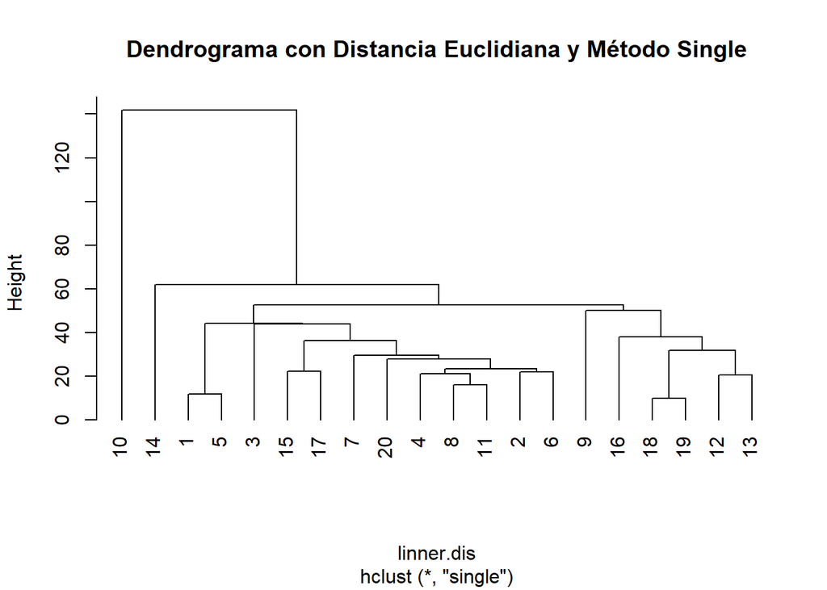

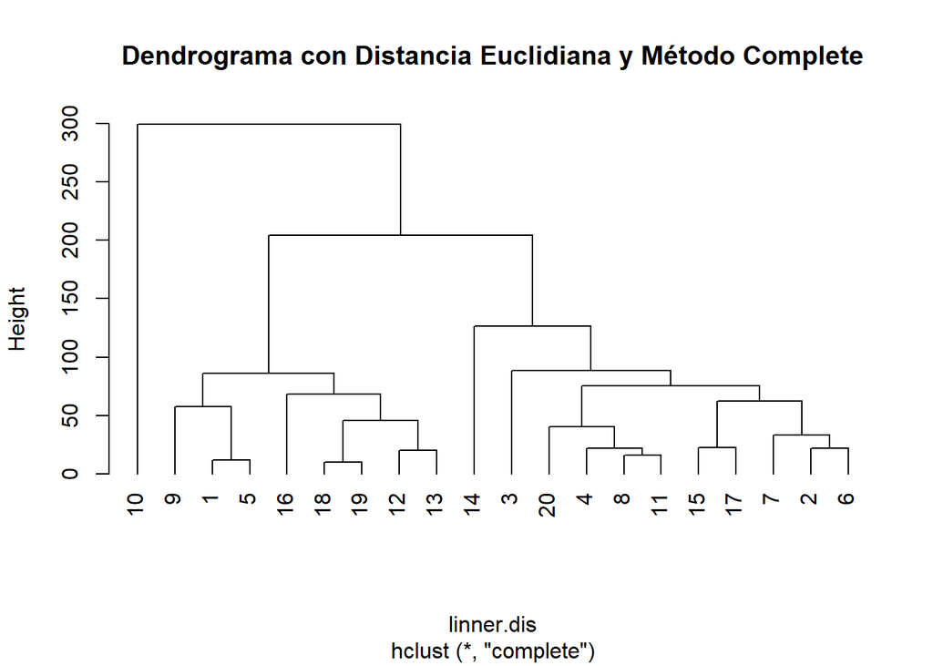

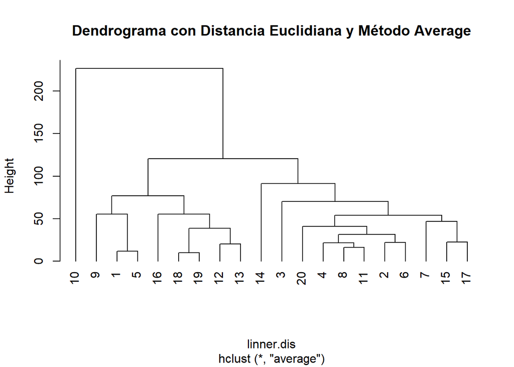

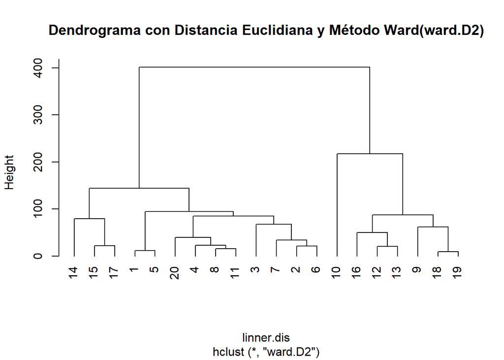

```r
#calculo de la matriz de distancia euclideana
linner.dis<-dist(linnerud)

#modelo con el metodo single
linhcl_s  <- hclust(d=linner.dis,method ="single")

#modelo con el metodo complete
linhcl_c  <- hclust(d=linner.dis,method ="complete")

#modelo con el metodo average
linhcl_av  <- hclust(d=linner.dis,method ="average")

#modelo con el metodo ward.d
linhcl_wd  <- hclust(d=linner.dis,method ="ward.D2")

# Dibujando los dendrograma
for(i in 1:1){
plot(linhcl_s, main = "Dendrograma con Distancia Euclidiana y Método Single",hang=-1)

plot(linhcl_c, main = "Dendrograma con Distancia Euclidiana y Método Complete",hang=-1)

plot(linhcl_av, main = "Dendrograma con Distancia Euclidiana y Método Average",hang=-1)

plot(linhcl_wd, main = "Dendrograma con Distancia Euclidiana y Método Ward(ward.D2)",hang=-1)
}
```

# PREGUNTA 9

¿Cual clasificación le parece mejor?

**Solucion**

Revisando los dendogramas del apartado 8, se observa que la que mejor hacer la clasificacion jerarquica es el endograma con el Metodo Ward.D2 y con la distancia Euclidenada. Esto se debe a que el arbol generado, esta mas balanceado que los otros arboles.